# Violin following study stats - master

Lucas Klein

Last updated: 29 August, 2022

# Prep and load

Two pieces:

```r
piece1 <- "Danny Boy"
piece2 <- "In The Garden"
section <- "whole" # Which section?
```

No NA’s found

### Pre-process

Both dataframes are currently in wide format, with a column for cross-correlation values. This removes the CC column and creates long-formatted dataframes for both pieces, including a combined version of both together. Then outputs these three dataframes in a list.

Recording to performance direction = 1 Performance to recording direction = 2

# Plots

Set title based on piece and section

## GC values by direction

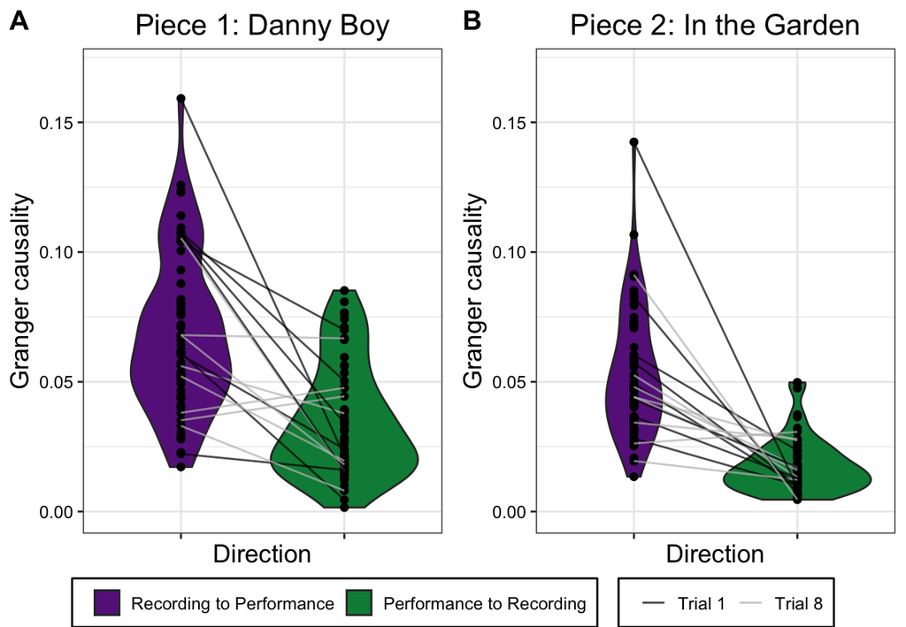

Violin plots for both pieces showing differences in GC values across both directions.

## GC and CC by trial

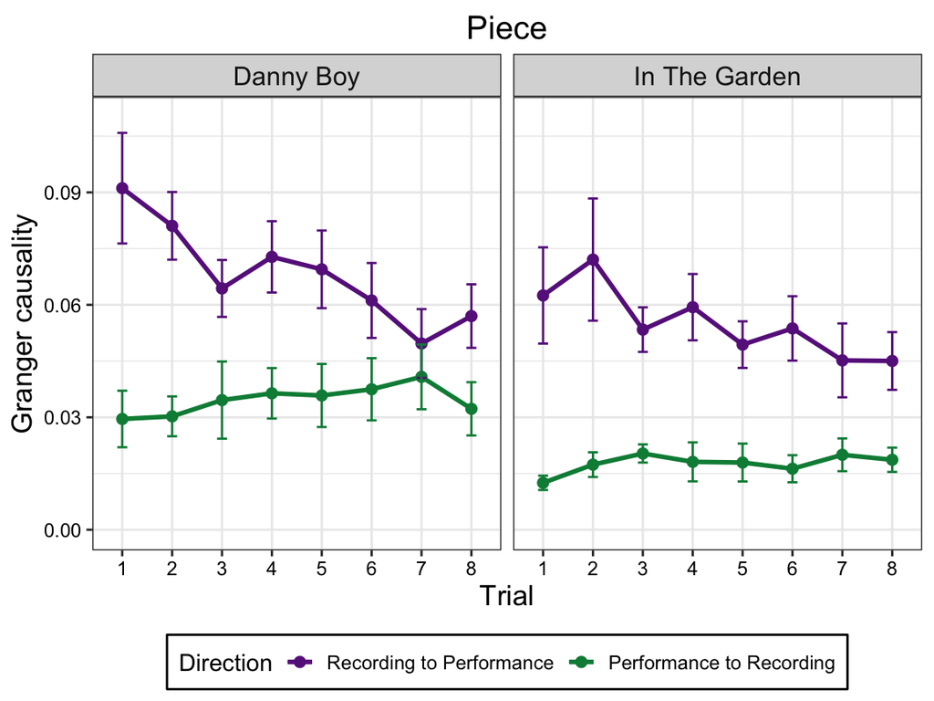

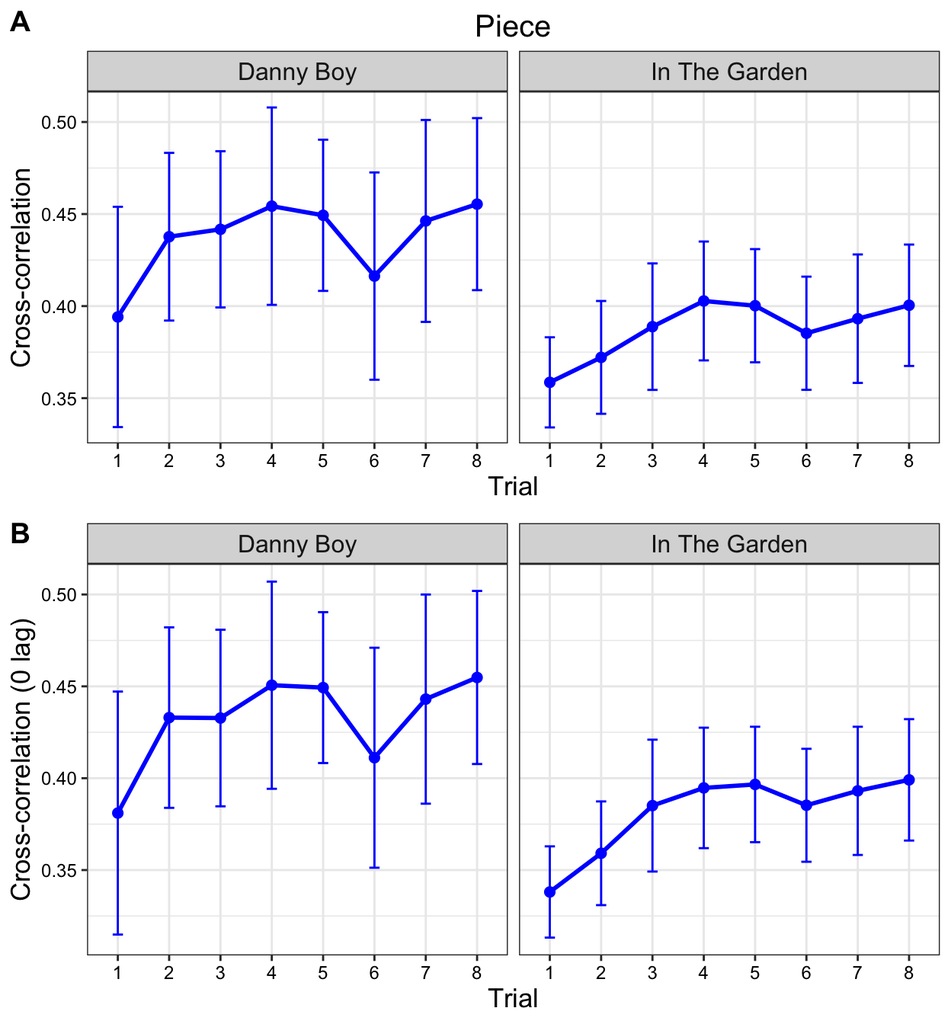

## Best lags by trials

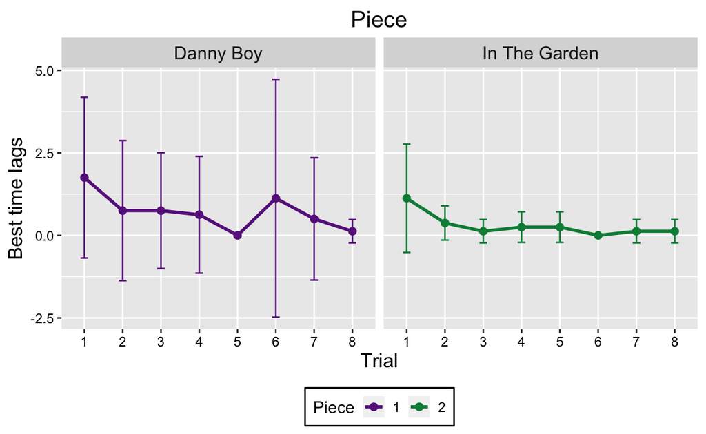

Means of all participants’ best time lags across trials for both pieces.

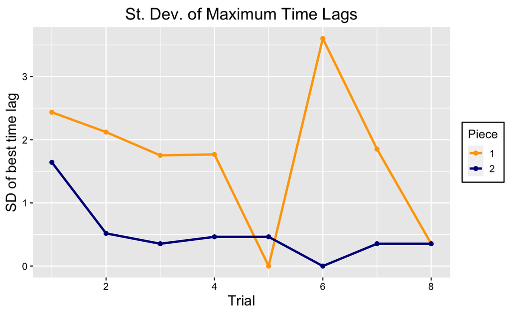

# Stats

## Information flow direction

### T-tests between directions

```
## [1] "Danny Boy: t =  7.038 , p =  1.71424766910585e-09"
```

```
## [1] "In The Garden: t =  9.659 , p =  4.76354191871746e-14"
```

## Changes in GC and CC across trials

### Linear mixed effects models

- lmer() function
- Automatically uses Type III SS

r2beta: r2beta Compute R Squared for Mixed Models  
t-value: slope is significantly NOT zero  
Estimate: slope of model, effect size  
chi squared - compares error  
Correlated fixed effects?

#### Linear models for Granger causality

```
## Data: x
## Models:
## mod.gc1[[1]]: GC ~ 1 + (1 | Participant)
## mod.gc1[[2]]: GC ~ 1 + Trial + (1 | Participant)
##              npar     AIC     BIC logLik deviance  Chisq Df Pr(>Chisq)
## mod.gc1[[1]]    3 -272.81 -266.34 139.41  -278.81
## mod.gc1[[2]]    4 -285.06 -276.42 146.53  -293.06 14.241  1  0.0001608 ***
## ---
## Signif. codes:  0 '***' 0.001 '**' 0.01 '*' 0.05 '.' 0.1 ' ' 1
```

```
## Data: x
## Models:
## mod.gc2[[1]]: GC ~ 1 + (1 | Participant)
## mod.gc2[[2]]: GC ~ 1 + Trial + (1 | Participant)
##              npar     AIC     BIC logLik deviance Chisq Df Pr(>Chisq)
## mod.gc2[[1]]    3 -310.04 -303.56 158.02  -316.04
## mod.gc2[[2]]    4 -320.45 -311.81 164.22  -328.45 12.41  1   0.000427 ***
## ---
## Signif. codes:  0 '***' 0.001 '**' 0.01 '*' 0.05 '.' 0.1 ' ' 1
```

```
## [1] "Danny Boy: beta =  -0.005  R-squared =  0.225  p-value =  0"
```

```
## [1] "ITG: beta =  -0.003  R-squared =  0.199  p-value =  0"
```

#### Linear models for Cross-correlation (full, not windowed)

```
## Data: x
## Models:
## mod.cc1[[1]]: CC ~ 1 + (1 | Participant)
## mod.cc1[[2]]: CC ~ 1 + Trial + (1 | Participant)
##              npar     AIC     BIC logLik deviance Chisq Df Pr(>Chisq)
## mod.cc1[[1]]    3 -179.66 -173.19 92.832  -185.66
## mod.cc1[[2]]    4 -181.64 -173.01 94.821  -189.64 3.978  1     0.0461 *
## ---
## Signif. codes:  0 '***' 0.001 '**' 0.01 '*' 0.05 '.' 0.1 ' ' 1
```

```
## Data: x
## Models:
## mod.cc2[[1]]: CC ~ 1 + (1 | Participant)
## mod.cc2[[2]]: CC ~ 1 + Trial + (1 | Participant)
##              npar     AIC     BIC logLik deviance  Chisq Df Pr(>Chisq)
## mod.cc2[[1]]    3 -185.09 -178.61 95.545  -191.09
## mod.cc2[[2]]    4 -186.70 -178.07 97.352  -194.70 3.6138  1     0.0573 .
## ---
## Signif. codes:  0 '***' 0.001 '**' 0.01 '*' 0.05 '.' 0.1 ' ' 1
```

```
## [1] "Danny Boy: beta =  0.005  R-squared =  0.069  p-value =  0.0461"
```

```
## [1] "In The Garden: beta =  0.005  R-squared =  0.062  p-value =  0.0573"
```

#### Linear mixed models for best lags across trials:

```
## Data: x
## Models:
## mod.cc1[[11]]: CC_l ~ 1 + (1 | Participant)
## mod.cc1[[12]]: CC_l ~ 1 + Trial + (1 | Participant)
##               npar    AIC    BIC  logLik deviance  Chisq Df Pr(>Chisq)
## mod.cc1[[11]]    3 249.79 256.26 -121.89   243.79
## mod.cc1[[12]]    4 248.22 256.86 -120.11   240.22 3.5693  1    0.05886 .
## ---
## Signif. codes:  0 '***' 0.001 '**' 0.01 '*' 0.05 '.' 0.1 ' ' 1
```

```
## Data: x
## Models:
## mod.cc2[[11]]: CC_l ~ 1 + (1 | Participant)
## mod.cc2[[12]]: CC_l ~ 1 + Trial + (1 | Participant)
##               npar    AIC    BIC  logLik deviance  Chisq Df Pr(>Chisq)
## mod.cc2[[11]]    3 145.54 152.01 -69.769   139.54
## mod.cc2[[12]]    4 139.93 148.56 -65.963   131.93 7.6112  1   0.005801 **
## ---
## Signif. codes:  0 '***' 0.001 '**' 0.01 '*' 0.05 '.' 0.1 ' ' 1
```

```
## [1] "Danny Boy: beta =  -0.144 , R-squared =  0.062 , p-value =  0.059"
```

```
## [1] "In The Garden: beta =  -0.103 , R-squared =  0.127 , p-value =  0.006"
```

#### Linear models for Cross-correlation - 0 LAG (synchrony)

```
## Data: x
## Models:
## mod.cc1[[9]]: CC0 ~ 1 + (1 | Participant)
## mod.cc1[[10]]: CC0 ~ 1 + Trial + (1 | Participant)
##               npar     AIC     BIC logLik deviance  Chisq Df Pr(>Chisq)
## mod.cc1[[9]]     3 -164.24 -157.77 85.122  -170.24
## mod.cc1[[10]]    4 -167.34 -158.70 87.669  -175.34 5.0935  1    0.02402 *
## ---
## Signif. codes:  0 '***' 0.001 '**' 0.01 '*' 0.05 '.' 0.1 ' ' 1
```

```
## Data: x
## Models:
## mod.cc2[[9]]: CC0 ~ 1 + (1 | Participant)
## mod.cc2[[10]]: CC0 ~ 1 + Trial + (1 | Participant)
##               npar     AIC     BIC logLik deviance  Chisq Df Pr(>Chisq)
## mod.cc2[[9]]     3 -182.54 -176.07 94.273  -188.54
## mod.cc2[[10]]    4 -189.36 -180.72 98.679  -197.36 8.8115  1   0.002993 **
## ---
## Signif. codes:  0 '***' 0.001 '**' 0.01 '*' 0.05 '.' 0.1 ' ' 1
```

```
## [1] "Danny Boy: beta =  0.006  R-squared =  0.087  p-value =  0.02402"
```

```
## [1] "In The Garden: beta =  0.007  R-squared =  0.146  p-value =  0.00299"
```

## Trend Analysis

Calculating linear contrasts (comparisons) among levels of a quantitative (ordered) factor Assumes equal subjects in each group

Trend analysis partitions the sum of squares for the model into portions due to linear trend, quadratic trend, cubic trend, etc. If there are k groups it is possible to look at up to k - 1 trends, although often researchers combine together all trends above quadratic or cubic.

### Trend analysis of Granger causality

```
## [1] "Danny Boy: F( 1 , 56 ) =  9.819  with p =  0.00275"
```

```
## [1] "In The Garden: F( 1 , 56 ) =  4.141  with p =  0.04661"
```

### Trend analysis of Cross-correlation

#### Similarity - CC (full function, not windowed) using best lag

```
## [1] "Danny Boy: F( 1 , 56 ) =  0.357  with p =  0.55277"
```

```
## [1] "In The Garden: F( 1 , 56 ) =  0.887  with p =  0.3504"
```

#### Synchrony - CC (full function, not windowed) using 0 lag

```
## [1] "Danny Boy: F( 1 , 56 ) =  0.519  with p =  0.47425"
```

```
## [1] "In The Garden: F( 1 , 56 ) =  2.135  with p =  0.14958"
```

#### 0 LAG - last four trials

```
## [1] "Danny Boy: F( 1 , 28 ) =  0.044  with p =  0.83596"
```

```
## [1] "In The Garden: F( 1 , 28 ) =  0.011  with p =  0.91675"
```

## Log-fit for CC

#### Danny Boy

#### In The Garden

## Correlations between GC and CC

### Different method

#### Danny Boy

#### In The Garden

# Save data

Save entire workspace image (all variables) as .Rdata file Save data frames as .rda files